# Pollution data analysis example

[figure not shown]

This tutorial uses data published by the Department of Computer Science and Engineering, Indian Institute of Technology Delhi, specifically: [Delhi Pollution Dataset](http://cse.iitd.ac.in/pollutiondata/delhi). The workflow consists of the following steps:

1. Establishing an overview by visualizing raw input data records
2. Converting data into trajectories
3. Removing problematic trajectories using ObservationGapSplitter and filtering by speed
4. Plotting cleaned trajectories
5. Assigning H3 cell IDs to each trajectory point
6. Plotting H3 cells as polygons with pollution measurements

Some of the steps working with H3 are based on the following: [Medium article](https://medium.com/@jesse.b.nestler/how-to-convert-h3-cell-boundaries-to-shapely-polygons-in-python-f7558add2f63).

```python
import numpy as np
import pandas as pd
import geopandas as gpd
import movingpandas as mpd
import shapely as shp
import hvplot.pandas
import matplotlib.pyplot as plt
import h3
import folium

from geopandas import GeoDataFrame, read_file
from shapely.geometry import Point, LineString, Polygon
from datetime import datetime, timedelta
from holoviews import opts, dim
from os.path import exists
from urllib.request import urlretrieve

import warnings

warnings.filterwarnings("ignore")

plot_defaults = {"linewidth": 5, "capstyle": "round", "figsize": (9, 3), "legend": True}
opts.defaults(
    opts.Overlay(active_tools=["wheel_zoom"], frame_width=300, frame_height=500)
)
hvplot_defaults = {"tiles": None, "cmap": "Viridis", "colorbar": True}

mpd.show_versions()
```

```
MovingPandas 0.23.0

SYSTEM INFO
-----------
python     : 3.10.19 | packaged by conda-forge | (main, Jan 26 2026, 23:45:08) [GCC 14.3.0]
executable : /home/anita/miniforge3/envs/mpd-ex/bin/python
machine    : Linux-6.8.0-134-generic-x86_64-with-glibc2.39

PROJ INFO
-----------
PROJ       : 9.6.2
PROJ data dir: /home/anita/miniforge3/envs/mpd-ex/share/proj

PYTHON DEPENDENCIES
-------------------
numpy      : 1.23.1
geopandas  : 1.0.1
geopy      : 2.4.1
geoviews   : 1.15.1
holoviews  : 1.22.1
hvplot     : 0.12.2
mapclassify: 2.8.1
matplotlib : 3.10.8
pandas     : 2.3.3
pyproj     : 3.7.1
shapely    : 2.1.2
stonesoup  : 1.8
```

## Loading pollution data

```python
%%time
df = pd.read_csv("../data/2021-01-30_all.zip", index_col=0)
print(f"Finished reading {len(df)}")
```

```
Finished reading 180573
CPU times: user 318 ms, sys: 24 ms, total: 342 ms
Wall time: 343 ms
```

Let's see what the data looks like:

```python
df.head()
```

|  | uid | dateTime | deviceId | lat | long | pm1_0 | pm2_5 | pm10 |
| --- | --- | --- | --- | --- | --- | --- | --- | --- |
| 0 | 0db83849-cd24-477a-a9d8-e48da1c914a3 | 2021-01-30 00:00:01+05:30 | 00000000c37f0aa8 | 28.579370 | 77.228798 | 94.0 | 142.0 | 156.0 |
| 1 | a77c4ff0-7723-418b-a02e-5653e9fa4530 | 2021-01-30 00:00:01+05:30 | 10000000dc5bb76b | 28.579414 | 77.231705 | 127.0 | 213.0 | 231.0 |
| 2 | f3109afa-7234-44a1-9911-b01646e33ed8 | 2021-01-30 00:00:04+05:30 | 10000000dc5bb76b | 28.579414 | 77.231705 | 126.0 | 214.0 | 231.0 |
| 3 | 39b07547-9467-45c6-85e9-3a917ce969f3 | 2021-01-30 00:00:04+05:30 | 00000000c37f0aa8 | 28.579367 | 77.228806 | 94.0 | 145.0 | 157.0 |
| 4 | 41b70559-af34-486d-975b-9de3bd30c0f0 | 2021-01-30 00:00:06+05:30 | 10000000dc5bb76b | 28.579414 | 77.231705 | 128.0 | 218.0 | 238.0 |

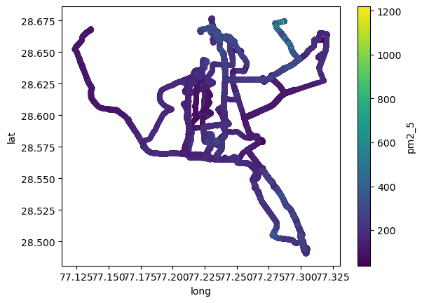

```python
df.plot(c="pm2_5", x="long", y="lat", kind="scatter")
```

Let's create trajectories:

```python
tc = mpd.TrajectoryCollection(df, "deviceId", t="dateTime", x="long", y="lat")
print(tc)
```

```
TrajectoryCollection with 11 trajectories
```

## Removing problematic trajectories

We use Particulate Matter (PM) as an indicator for air pollution:

```python
traj_gdf = tc.to_traj_gdf(agg={"pm2_5": "mean"})
```

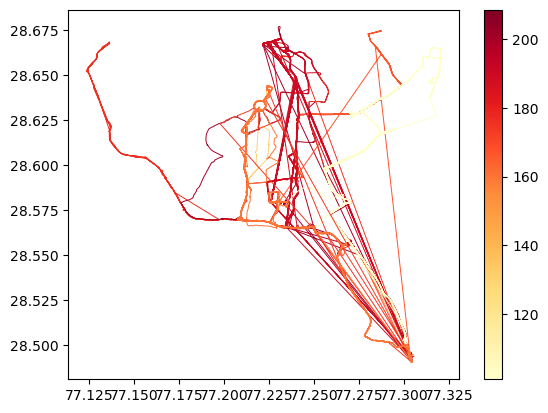

```python
traj_gdf.plot("pm2_5_mean", cmap="YlOrRd", linewidth=0.7, legend=True, aspect=1)
```

Let's remove problematic trajectories as much as we can:

```python
split = mpd.ObservationGapSplitter(tc).split(gap=timedelta(minutes=10))
split
```

TrajectoryCollection with 76 trajectories

Trajectory 00000000078e6811_0 (No. rows: 1110 | Length: 15.8 km)

| Start: 2021-01-30 20:21:24 | End: 2021-01-30 21:18:39 | Duration: 0:57:15 |
| --- | --- | --- |
| Bounds: (77.224586, 28.516333000000003, 77.296288, 28.584982) |  | CRS: epsg:4326 |
| Columns: uid (object), deviceId (object), pm1_0 (float64), pm2_5 (float64), pm10 (float64) |  |  |

**Data preview**

| dateTime | uid | deviceId | pm1_0 | pm2_5 | pm10 | geometry |
| --- | --- | --- | --- | --- | --- | --- |
| 2021-01-30 20:21:24 | 448ffd36-bb67-405a-b148-1274588a07e6 | 00000000078e6811_0 | 129.0 | 210.0 | 242.0 | POINT (77.29629 28.51633) |
| 2021-01-30 20:21:26 | 0ee79e60-ad3f-413b-853b-d2b70123a17c | 00000000078e6811_0 | 128.0 | 213.0 | 250.0 | POINT (77.2962 28.51653) |
| 2021-01-30 20:21:29 | 28245f16-1106-4ab0-81bf-099de4e48d79 | 00000000078e6811_0 | 128.0 | 212.0 | 251.0 | POINT (77.29612 28.51673) |
| 2021-01-30 20:21:33 | d0994c8b-208e-4bff-8afc-b091feac1162 | 00000000078e6811_0 | 128.0 | 213.0 | 254.0 | POINT (77.29602 28.51699) |
| 2021-01-30 20:21:35 | 56060040-e26b-4495-9a9a-20156a8a20bd | 00000000078e6811_0 | 131.0 | 213.0 | 258.0 | POINT (77.29593 28.51722) |

Trajectory 0000000024568afd_0 (No. rows: 2435 | Length: 52.9 km)

| Start: 2021-01-30 04:58:32 | End: 2021-01-30 07:17:29 | Duration: 2:18:57 |
| --- | --- | --- |
| Bounds: (77.123878, 28.490446, 77.304123, 28.667912) |  | CRS: epsg:4326 |
| Columns: uid (object), deviceId (object), pm1_0 (float64), pm2_5 (float64), pm10 (float64) |  |  |

**Data preview**

| dateTime | uid | deviceId | pm1_0 | pm2_5 | pm10 | geometry |
| --- | --- | --- | --- | --- | --- | --- |
| 2021-01-30 04:58:32 | c1c0dd83-9bff-420a-b4e5-50bc0f603d59 | 0000000024568afd_0 | 108.0 | 198.0 | 211.0 | POINT (77.22741 28.57927) |
| 2021-01-30 04:58:35 | d8678c0b-9016-46f7-ba43-4b6ebf83a393 | 0000000024568afd_0 | 109.0 | 197.0 | 211.0 | POINT (77.22738 28.57932) |
| 2021-01-30 04:58:38 | 317f0a87-2378-4255-984b-ccfd009704b8 | 0000000024568afd_0 | 109.0 | 197.0 | 213.0 | POINT (77.22735 28.57937) |
| 2021-01-30 04:58:41 | 90ee48d7-7251-4af3-9c73-7d85810cde01 | 0000000024568afd_0 | 109.0 | 198.0 | 212.0 | POINT (77.22739 28.57935) |
| 2021-01-30 04:58:43 | b2e3873c-5adb-44ba-bd73-b0dfe3fe22fb | 0000000024568afd_0 | 111.0 | 198.0 | 213.0 | POINT (77.22742 28.57933) |

Trajectory 0000000024568afd_1 (No. rows: 2179 | Length: 33.7 km)

| Start: 2021-01-30 07:33:57 | End: 2021-01-30 09:22:37 | Duration: 1:48:40 |
| --- | --- | --- |
| Bounds: (77.124344, 28.490522, 77.30413100000001, 28.667635) |  | CRS: epsg:4326 |
| Columns: uid (object), deviceId (object), pm1_0 (float64), pm2_5 (float64), pm10 (float64) |  |  |

**Data preview**

| dateTime | uid | deviceId | pm1_0 | pm2_5 | pm10 | geometry |
| --- | --- | --- | --- | --- | --- | --- |
| 2021-01-30 07:33:57 | b666a1f2-1eb6-43c3-83b2-ec0bba9d3974 | 0000000024568afd_1 | 117.0 | 208.0 | 221.0 | POINT (77.13642 28.66739) |
| 2021-01-30 07:34:00 | c23ba6ec-d132-4f1c-b65c-2a9474ed8a2d | 0000000024568afd_1 | 118.0 | 207.0 | 221.0 | POINT (77.13638 28.66738) |
| 2021-01-30 07:34:02 | 5fe64ab1-5dd7-4136-8a2f-a8024e49f32f | 0000000024568afd_1 | 119.0 | 207.0 | 221.0 | POINT (77.13635 28.66738) |
| 2021-01-30 07:34:05 | ad4f6697-e6aa-440e-a88e-aa313575754d | 0000000024568afd_1 | 120.0 | 207.0 | 219.0 | POINT (77.13632 28.6674) |
| 2021-01-30 07:34:08 | 6d175523-3384-4e35-b111-553459c6a89b | 0000000024568afd_1 | 121.0 | 209.0 | 222.0 | POINT (77.1363 28.66742) |

Trajectory 0000000024568afd_2 (No. rows: 699 | Length: 11.8 km)

| Start: 2021-01-30 10:53:26 | End: 2021-01-30 11:30:20 | Duration: 0:36:54 |
| --- | --- | --- |
| Bounds: (77.197151, 28.539103000000004, 77.28286, 28.569958000000003) |  | CRS: epsg:4326 |
| Columns: uid (object), deviceId (object), pm1_0 (float64), pm2_5 (float64), pm10 (float64) |  |  |

**Data preview**

| dateTime | uid | deviceId | pm1_0 | pm2_5 | pm10 | geometry |
| --- | --- | --- | --- | --- | --- | --- |
| 2021-01-30 10:53:26 | 0f71ea56-9ea1-4415-bdc7-98adb251d31a | 0000000024568afd_2 | 102.0 | 175.0 | 188.0 | POINT (77.28286 28.5391) |
| 2021-01-30 10:53:29 | 09809da7-e627-4ce0-8aec-b7b0bcbd9b11 | 0000000024568afd_2 | 102.0 | 175.0 | 191.0 | POINT (77.28271 28.53927) |
| 2021-01-30 10:53:32 | e399ea32-9d81-4508-a2d2-d02f56b20d77 | 0000000024568afd_2 | 101.0 | 176.0 | 193.0 | POINT (77.28262 28.53942) |
| 2021-01-30 10:53:35 | 56ca58b8-be4b-449e-b092-18359cac3c64 | 0000000024568afd_2 | 101.0 | 176.0 | 192.0 | POINT (77.28253 28.53958) |
| 2021-01-30 10:53:38 | f19d44f5-b561-49d1-8268-77120b615c88 | 0000000024568afd_2 | 103.0 | 178.0 | 195.0 | POINT (77.28244 28.53974) |

Trajectory 0000000024568afd_3 (No. rows: 833 | Length: 14.4 km)

| Start: 2021-01-30 11:53:30 | End: 2021-01-30 12:44:52 | Duration: 0:51:22 |
| --- | --- | --- |
| Bounds: (77.1726, 28.54084000000001, 77.282059, 28.584423) |  | CRS: epsg:4326 |
| Columns: uid (object), deviceId (object), pm1_0 (float64), pm2_5 (float64), pm10 (float64) |  |  |

**Data preview**

| dateTime | uid | deviceId | pm1_0 | pm2_5 | pm10 | geometry |
| --- | --- | --- | --- | --- | --- | --- |
| 2021-01-30 11:53:30 | 252049f4-e37a-496f-bb60-5d25b0711fff | 0000000024568afd_3 | 112.0 | 210.0 | 235.0 | POINT (77.17295 28.58442) |
| 2021-01-30 11:53:33 | c7d25195-3c6c-4d52-80ca-3d4bef7c71dd | 0000000024568afd_3 | 116.0 | 218.0 | 243.0 | POINT (77.17294 28.58439) |
| 2021-01-30 11:53:35 | f7c7e202-fce0-49a4-a2ee-74af9c5a150b | 0000000024568afd_3 | 117.0 | 216.0 | 240.0 | POINT (77.17294 28.58438) |
| 2021-01-30 11:53:38 | 19449a2f-a865-434c-8957-b2aa56d5ce11 | 0000000024568afd_3 | 113.0 | 212.0 | 239.0 | POINT (77.1729 28.58434) |
| 2021-01-30 11:53:41 | ea67caf4-ff27-447e-b4ba-e9245d9f26cf | 0000000024568afd_3 | 113.0 | 208.0 | 238.0 | POINT (77.17288 28.58432) |

... and 71 more trajectories

```python
split = split.add_speed(units=("km", "h"))
```

```python
traj_gdf = split.to_traj_gdf(agg={"pm2_5": "mean", "speed": "max"})
```

Anything over a speed of 108km/h or 30m/s seems unlikely for a bus, so let's filter these points out:

```python
traj_gdf = traj_gdf[traj_gdf.speed_max < 108]
```

## Plotting trajectories

Let's plot the resulting trajectories:

```python
traj_gdf["start_t"] = traj_gdf["start_t"].astype(str)
traj_gdf["end_t"] = traj_gdf["end_t"].astype(str)
```

```python
traj_gdf = traj_gdf.round(2)
```

```python
traj_gdf.explore(
    column="pm2_5_mean",
    cmap="YlOrRd",
    tiles="CartoDB positron",
    style_kwds={"weight": 4},
)
```

Make this Notebook Trusted to load map: File -> Trust Notebook

[interactive chart not shown]

## Assigning H3 cell IDs to trajectory points

Let's again filter by realistic speed:

```python
point_gdf = split.to_point_gdf()
```

```python
point_gdf = point_gdf[point_gdf.speed < 30]
```

```python
point_gdf["x"] = point_gdf.geometry.x
point_gdf["y"] = point_gdf.geometry.y
```

We can assign H3 cell IDs to each point in a trajectory:

```python
res = 7
point_gdf["h3_cell"] = point_gdf.apply(
    lambda r: str(h3.latlng_to_cell(r.y, r.x, res)), axis=1
)
point_gdf.head()
```

| dateTime | uid | deviceId | pm1_0 | pm2_5 | pm10 | geometry | speed | x | y | h3_cell |
| --- | --- | --- | --- | --- | --- | --- | --- | --- | --- | --- |
| 2021-01-30 20:21:29 | 28245f16-1106-4ab0-81bf-099de4e48d79 | 00000000078e6811_0 | 128.0 | 212.0 | 251.0 | POINT (77.29612 28.51673) | 27.443267 | 77.296121 | 28.516728 | 873da1072ffffff |
| 2021-01-30 20:21:33 | d0994c8b-208e-4bff-8afc-b091feac1162 | 00000000078e6811_0 | 128.0 | 213.0 | 254.0 | POINT (77.29602 28.51699) | 27.443262 | 77.296021 | 28.516989 | 873da1072ffffff |
| 2021-01-30 20:21:38 | 55c47d6c-4c15-4807-8897-76cf1398ef3a | 00000000078e6811_0 | 133.0 | 215.0 | 261.0 | POINT (77.29585 28.51742) | 28.561704 | 77.295853 | 28.517420 | 873da1072ffffff |
| 2021-01-30 20:24:58 | 17d49dee-4b05-461a-83d3-4d95a12a02cc | 00000000078e6811_0 | 140.0 | 227.0 | 260.0 | POINT (77.28574 28.53448) | 28.693861 | 77.285744 | 28.534485 | 873da1074ffffff |
| 2021-01-30 20:25:51 | 738dab30-4b15-4b26-b5da-cad595527d3c | 00000000078e6811_0 | 138.0 | 213.0 | 243.0 | POINT (77.28287 28.53916) | 17.840033 | 77.282872 | 28.539160 | 873da1074ffffff |

We can use the mean of PM2.5 as a pollution measurement:

```python
h3_df_mean = point_gdf.groupby(["h3_cell"])["pm2_5"].mean().round(0).reset_index()
h3_df_mean = h3_df_mean.rename(columns={"pm2_5": "pm2_5_mean"})
h3_df_mean.head()
```

|  | h3_cell | pm2_5_mean |
| --- | --- | --- |
| 0 | 873da1009ffffff | 178.0 |
| 1 | 873da100dffffff | 203.0 |
| 2 | 873da1054ffffff | 128.0 |
| 3 | 873da1070ffffff | 153.0 |
| 4 | 873da1072ffffff | 159.0 |

We can also use the maximum of PM2.5 as a pollution measurement:

```python
h3_df_max = point_gdf.groupby(["h3_cell"])["pm2_5"].max().reset_index()
h3_df_max = h3_df_max.rename(columns={"pm2_5": "pm2_5_max"})
h3_df_max.head()
```

|  | h3_cell | pm2_5_max |
| --- | --- | --- |
| 0 | 873da1009ffffff | 819.0 |
| 1 | 873da100dffffff | 659.0 |
| 2 | 873da1054ffffff | 1007.0 |
| 3 | 873da1070ffffff | 532.0 |
| 4 | 873da1072ffffff | 408.0 |

## Visualizing pollution measurements

Let's create polygons with pollution data:

```python
def cell_to_shapely(cell):
    coords = h3.cell_to_boundary(cell)
    flipped = tuple(coord[::-1] for coord in coords)
    return Polygon(flipped)


h3_geoms_mean = h3_df_mean["h3_cell"].apply(lambda x: cell_to_shapely(x))
h3_gdf_mean = gpd.GeoDataFrame(data=h3_df_mean, geometry=h3_geoms_mean, crs=4326)

h3_geoms_max = h3_df_max["h3_cell"].apply(lambda x: cell_to_shapely(x))
h3_gdf_max = gpd.GeoDataFrame(data=h3_df_max, geometry=h3_geoms_max, crs=4326)
```

Let's plot the results for mean pollution data:

```python
h3_gdf_mean.explore(column="pm2_5_mean", cmap="YlOrRd")
```

Make this Notebook Trusted to load map: File -> Trust Notebook

[interactive chart not shown]

We can plot polygons and trajectories together:

```python
map = h3_gdf_mean.explore(column="pm2_5_mean", cmap="YlOrRd", name="PM2.5 mean")

traj_gdf.explore(m=map, name="Bus trajectories")

folium.TileLayer("Cartodb Positron").add_to(map)

folium.LayerControl().add_to(map)

map
```

Make this Notebook Trusted to load map: File -> Trust Notebook

[interactive chart not shown]

Lastly, let's plot mean and maximum values next to each other for comparison:

```python
h3_gdf_max = h3_gdf_max.rename(columns={"geometry": "geometry1"})
```

```python
pollution = pd.concat([h3_gdf_mean, h3_gdf_max], axis=1)
```

```python
(
    pollution.hvplot.polygons(
        geo=True, tiles="OSM", c="pm2_5_mean", alpha=0.8, title="Mean pollution data"
    )
    + pollution.hvplot.polygons(
        geo=True, tiles="OSM", c="pm2_5_max", alpha=0.8, title="Maximum pollution data"
    )
)
```

[output not shown]

## Continue exploring MovingPandas

1. Bird migration analysis
2. Ship data analysis
3. Horse collar data exploration
4. OSM traces
5. Soccer game
6. Mars rover & heli
7. Ever Given
8. Iceberg
9. Pollution data